# A Study on the Prevalence of Obesity, Cholesterol, Diabetes and Other Factors

## Model 2: Gender as the independent variables X1

Our hypothesis is that female has higher risk of contracting diabetes than males

We used boxplot and Mean plot with t-test to determine the validity of the hypothesis.

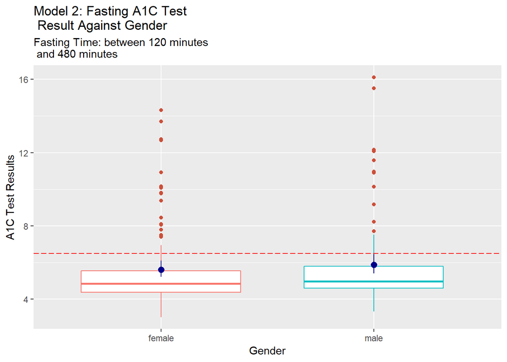

```r
##  Female has higher risk than male
#   Data set 3 is chosen for analysis

#   Boxplot with mean

diabetes480 %>% ggplot(aes(x = gender, y = glyhb)) +
  geom_boxplot(aes(color = gender), na.rm = TRUE, varwidth = TRUE,
               outlier.colour = "tomato3", outlier.size = 1.5) +
  stat_summary(fun.data = mean_cl_boot, geom = "pointrange", col = "darkblue") +
  geom_hline(yintercept = 6.5, color = "red", linetype="longdash") +
  labs(x = "Gender", y = "A1C Test Results",
       title = "Model 2: Fasting A1C Test\n Result Against Gender",
       subtitle = "Fasting Time: between 120 minutes\n and 480 minutes") +
  theme(legend.position = "none")
```

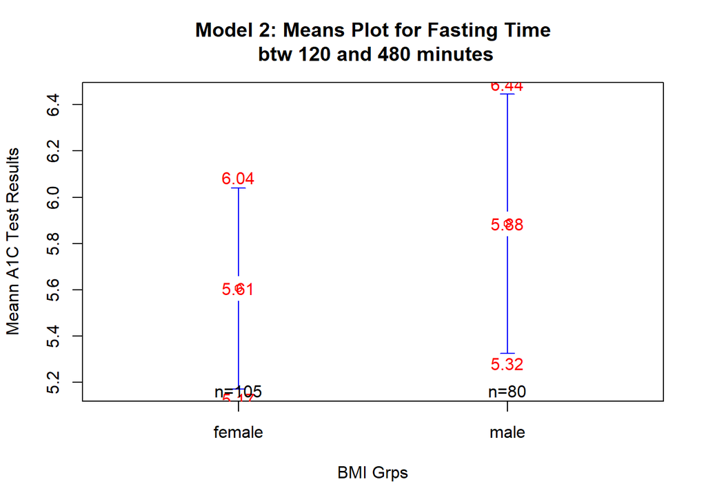

```r
#   Mean plot for gender

plotmeans(diabetes480$glyhb ~ diabetes480$gender, digits = 2, col = "red",
          mean.labels = T, ci = TRUE, ccol = "cyan4", lwd = 2, connect = FALSE,
          xlab = "BMI Grps", ylab = "Meann A1C Test Results",
          main = "Model 2: Means Plot for Fasting Time\n btw 120 and 480 minutes")
```

```r
#   Test based on Gender
#   Bartlett test - test homogeneity variance for assumption to decide which
#   t-test to use.

bartlett.test(glyhb ~ gender, data = diabetes480)
```

```
##
##  Bartlett test of homogeneity of variances
##
## data:  glyhb by gender
## Bartlett's K-squared = 1.1476, df = 1, p-value = 0.2841
```

```r
##  data:  glyhb by gender
##  Bartlett's K-squared = 1.1476, df = 1, p-value = 0.2841

# p-value = 0.284: use var.equal = T for t.test

t.test(glyhb ~ gender, var.equal = T, data = diabetes480)
```

```
##
##  Two Sample t-test
##
## data:  glyhb by gender
## t = -0.79427, df = 183, p-value = 0.4281
## alternative hypothesis: true difference in means is not equal to 0
## 95 percent confidence interval:
##  -0.9721738  0.4141024
## sample estimates:
## mean in group female   mean in group male
##             5.605714             5.884750
```

## Visualize 3: Gender interaction with Age Group and Frame

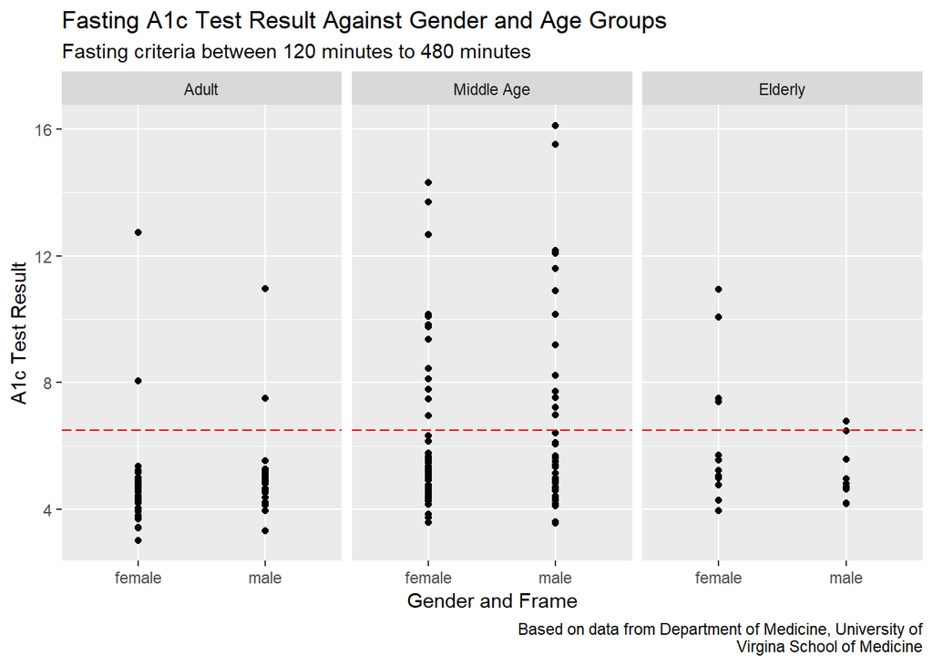

```r
#   Female and Male Comparison
#   With Age Group

ggplot(data=diabetes480) +
  geom_point(mapping = aes(x = gender, y = glyhb), na.rm = TRUE) +
  facet_wrap(age_grp ~ .) +
  geom_hline(yintercept = 6.5, color = "red", linetype="longdash") +
  labs(x = "Gender and Frame", y = "A1c Test Result",
       title = "Fasting A1c Test Result Against Gender and Age Groups",
       subtitle = "Fasting criteria between 120 minutes to 480 minutes",
       caption = "Based on data from Department of Medicine, University of
       Virgina School of Medicine")
```

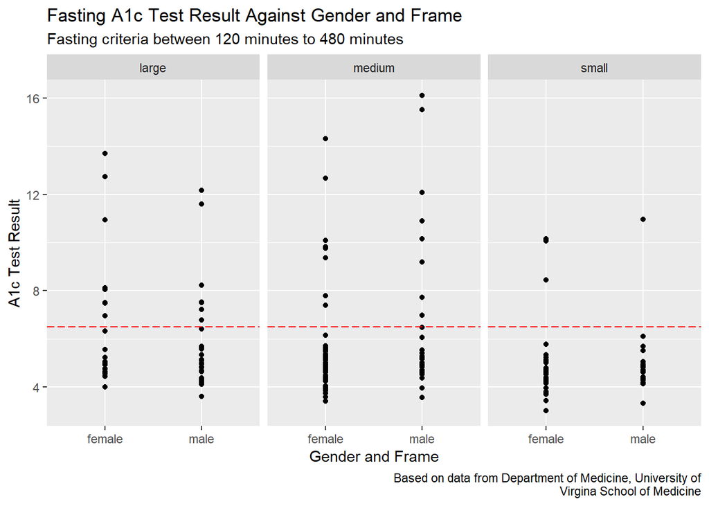

```r
#   With Frame

ggplot(data=diabetes480) +
  geom_point(mapping = aes(x = gender, y = glyhb), na.rm = TRUE) +
  facet_wrap(. ~ frame) +
  geom_hline(yintercept = 6.5, color = "red", linetype="longdash") +
  labs(x = "Gender and Frame", y = "A1c Test Result",
       title = "Fasting A1c Test Result Against Gender and Frame",
       subtitle = "Fasting criteria between 120 minutes to 480 minutes",
       caption = "Based on data from Department of Medicine, University of
       Virgina School of Medicine")
```

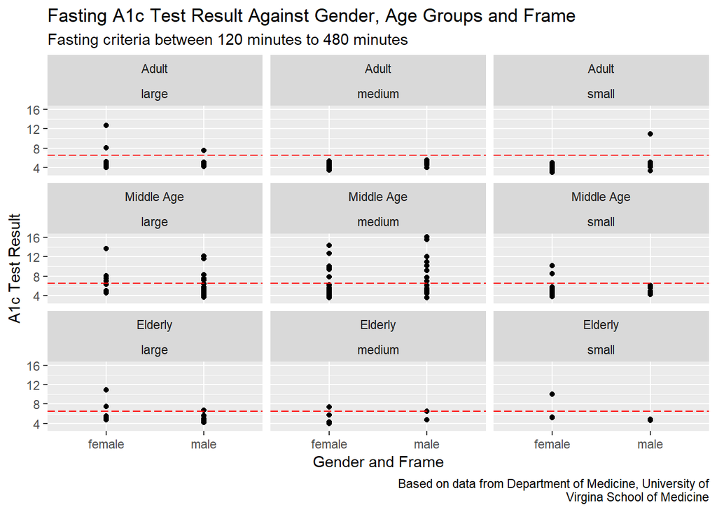

```r
#   With Age Group and Frame

ggplot(data=diabetes480) +
  geom_point(mapping = aes(x = gender, y = glyhb), na.rm = TRUE) +
  facet_wrap(age_grp ~ frame) +
  geom_hline(yintercept = 6.5, color = "red", linetype="longdash") +
  labs(x = "Gender and Frame", y = "A1c Test Result",
       title = "Fasting A1c Test Result Against Gender, Age Groups and Frame",
       subtitle = "Fasting criteria between 120 minutes to 480 minutes",
       caption = "Based on data from Department of Medicine, University of
       Virgina School of Medicine")
```

```r
##  Data set 3: Visualize correlation table: Correlogram
#   Set Female = 1 and Male = 0

diabetes480$female <- NA
diabetes480$female[diabetes480$gender == "female"] <- 1
diabetes480$female[diabetes480$gender == "male"] <- 0

#   Select relevant variables

d480_select <- diabetes480 %>% dplyr::select(age, glyhb, female)

glimpse(d480_select)
```

```
## Observations: 185
## Variables: 3
## $ age    <int> 29, 58, 67, 64, 34, 45, 55, 60, 36, 33, 50, 36, 47, 38,...
## $ glyhb  <dbl> 4.44, 4.64, 4.63, 7.72, 4.81, 4.84, 5.78, 4.77, 4.67, 3...
## $ female <dbl> 1, 1, 0, 0, 0, 0, 1, 1, 0, 1, 1, 0, 0, 1, 1, 1, 0, 0, 0...
```

```r
#   Compute Correlation matrix

corr_table <- round(cor(d480_select), 3)
corr_table
```

```
##           age  glyhb female
## age     1.000  0.305 -0.072
## glyhb   0.305  1.000 -0.059
## female -0.072 -0.059  1.000
```

```r
#   Compute a matrix of correlation p-values

p_mat <- cor_pmat(d480_select)
p_mat
```

```
##                 age        glyhb    female
## age    0.000000e+00 2.351948e-05 0.3270223
## glyhb  2.351948e-05 0.000000e+00 0.4280654
## female 3.270223e-01 4.280654e-01 0.0000000
```

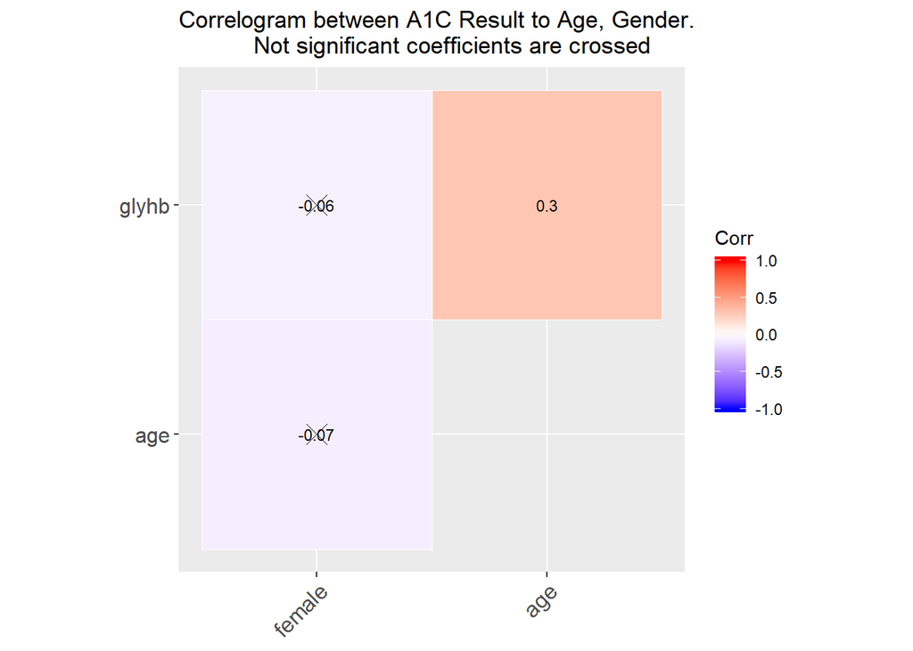

```r
#   Visual the Correlogram barring the no significant coefficient

ggcorrplot(corr_table,
           hc.order = T,
           type = "upper",
           lab = T,
           lab_size = 3,
           method="square",
           colors = c("blue", "white", "red"),
           outline.color = "white",
           p.mat = p_mat,
           title="Correlogram between A1C Result to Age, Gender.
           Not significant coefficients are crossed",
           ggtheme=theme_grey())
```

Visual Analysis:

1. Gender and Age: Age could be a co-founding factor to increase the risk of diabetic for both genders.
2. Gender and Frame: Medium to large frame size can influence the risk of diabetic for both genders
3. Gender, Age and Frame: Age is a more signifcant factor in the risk of diabetic prevalence in both genders and all frame size.

The Correlogram indicates that Age has a positive correlationship with A1C Test result.

## Model 3: Waist-Hip Ratio - An alternative to BMI

We proceed with analysis of Waist-Hip Ratio (an alternative measurement of obseity), including the interaction with frame size.

```r
######################################################
##    ANOVA One-Factor
#     Calculate and display the means for each whr_grp

means_whr_grp_c <- round(tapply(diabetes480$glyhb,
                                diabetes480$whr_grp, mean), digits = 2)
means_whr_grp_c
```

```
## High  Mod
## 6.07 5.56
```

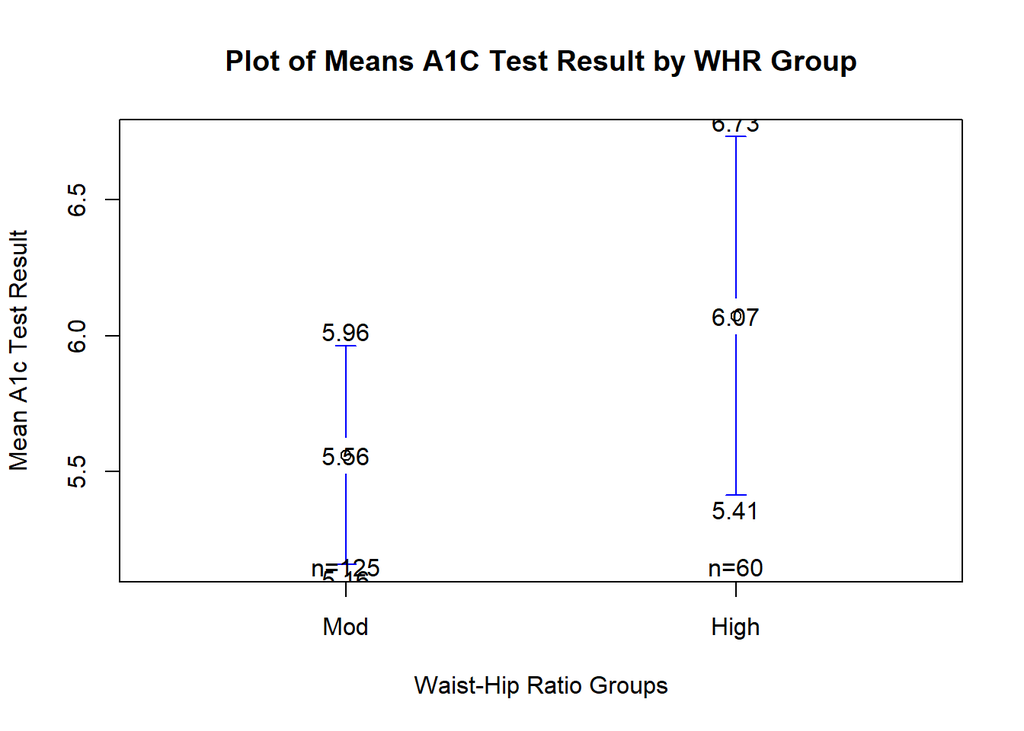

```r
#   Plot the Means

diabetes480$whr_grp <- reorder(diabetes480$whr_grp, diabetes480$whr)

plotmeans(diabetes480$glyhb ~ diabetes480$whr_grp, digits = 2, ccol = "red", ci = TRUE, lwd = 2, connect = FALSE,
          mean.labels = T, xlab = "Waist-Hip Ratio Groups", ylab = "Mean A1c Test Result",
          main = "Plot of Means A1C Test Result by WHR Group")
```

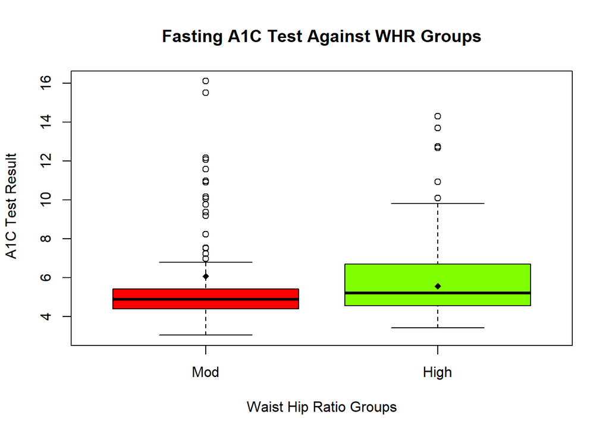

```r
##    boxplot with WHR Groups' means
#     Visualise the boxplot with the means

boxplot(diabetes480$glyhb ~ diabetes480$whr_grp,
        main = "Fasting A1C Test Against WHR Groups",
        xlab = "Waist Hip Ratio Groups",
        ylab = " A1C Test Result",
        col = rainbow(4))
points(means_whr_grp_c, col="black", pch=18)
```

```r
##   ANOVA of whr_grp as predictors for glyhb outcome

obj_aov_c <- aov(glyhb ~ whr_grp, data = diabetes480)
summary (obj_aov_c)
```

```
##              Df Sum Sq Mean Sq F value Pr(>F)
## whr_grp       1   10.6  10.618   1.908  0.169
## Residuals   183 1018.4   5.565
```

```r
#   From the result, there is no sigficant relationship between WHR groups and A1c Test Result.
#   P value is more than 0.05. Not necessary to do TukeyHSD test.

#   Two factors ANOVA test between whr_grp and frame
#   Testing for main between X and X2

obj_aov_main_c <- aov(glyhb ~ whr_grp + frame, data = diabetes480)
summary(obj_aov_main_c)
```

```
##              Df Sum Sq Mean Sq F value Pr(>F)
## whr_grp       1   10.6  10.618   1.961 0.1631
## frame         2   38.3  19.141   3.535 0.0312 *
## Residuals   181  980.1   5.415
## ---
## Signif. codes:  0 '***' 0.001 '**' 0.01 '*' 0.05 '.' 0.1 ' ' 1
```

```r
#   Testing for interaction between X and X2

obj_aov_inter_c <- aov(glyhb ~ whr_grp * frame, data = diabetes480)
summary(obj_aov_inter_c)
```

```
##                Df Sum Sq Mean Sq F value Pr(>F)
## whr_grp         1   10.6  10.618   1.949 0.1644
## frame           2   38.3  19.141   3.514 0.0318 *
## whr_grp:frame   2    5.1   2.543   0.467 0.6277
## Residuals     179  975.1   5.447
## ---
## Signif. codes:  0 '***' 0.001 '**' 0.01 '*' 0.05 '.' 0.1 ' ' 1
```

## Model 4: Correlationship between Cholesterol and A1C Results(Diabetes)

Next we work on to ascertain that High Cholesterols and A1C (glucose level) are correlated positively. If there is co-relation, which of the 3 groups has most significance? We find out the means and standard deviation between the 3 chol_grps followed by using the ANOVA 1-factor for our analysis.

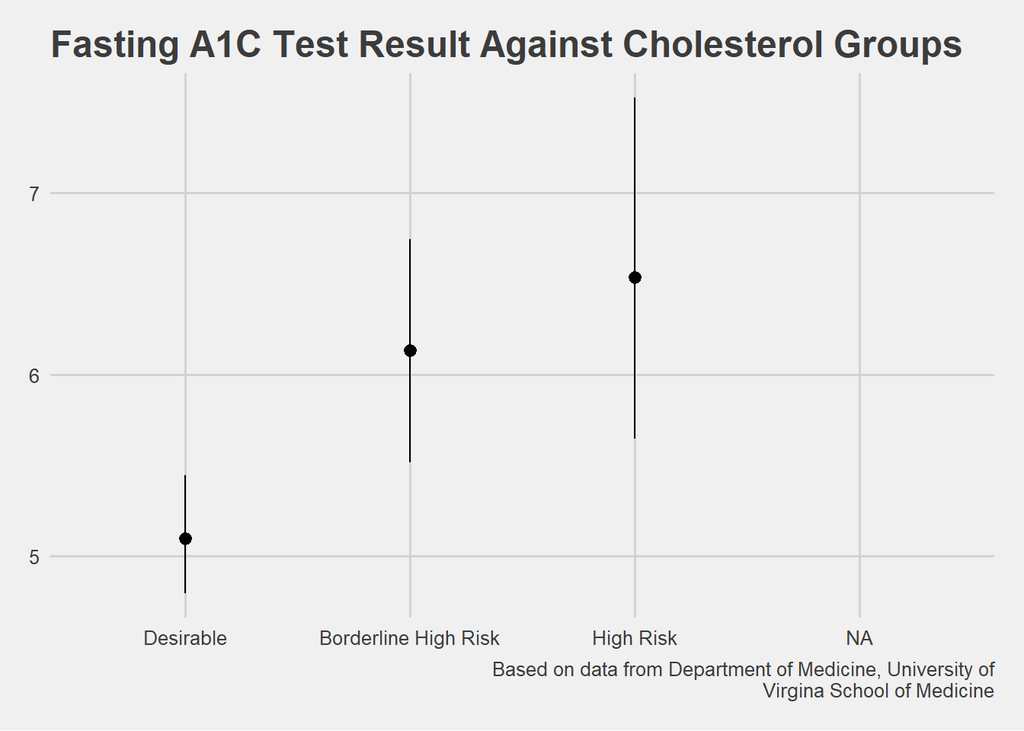

```r
###########################################################################
##    Modelling : A1C Results Against Total Cholesterol (chol) and
##    Cholesterol Group (chol_grp)
#     Both y (glyhb) and x (chol) are continuous / numerical type of data
###########################################################################

##    Modelling : Linear

# Reoder chol_grp according to chol

diabetes480$chol_grp <- reorder(diabetes480$chol_grp, diabetes480$chol)

### Modeling using ggplot

diabetes480 %>%
  ggplot(aes(x = chol_grp, y = glyhb, na.rm = TRUE)) +
  stat_summary(fun.data = mean_cl_boot, geom="pointrange") +
  labs(x = "Total Cholesterol", y = "A1C Test Result",
       caption = "Based on data from Department of Medicine, University of
       Virgina School of Medicine",
       title = "Fasting A1C Test Result Against Cholesterol Groups") +
  scale_x_discrete(labels = c("Desirable","Borderline High Risk",
                              "High Risk")) +
  ggthemes::theme_fivethirtyeight()
```

```r
# ANOVA using summary()

obj_aov_chol <- aov(glyhb~chol_grp, data = diabetes480)
summary(obj_aov_chol)
```

```
##              Df Sum Sq Mean Sq F value  Pr(>F)
## chol_grp      2   71.6   35.82   6.775 0.00145 **
## Residuals   181  957.1    5.29
## ---
## Signif. codes:  0 '***' 0.001 '**' 0.01 '*' 0.05 '.' 0.1 ' ' 1
## 1 observation deleted due to missingness
```

```r
# ANOVA using tidy()

diabetes480 %>%
  aov(glyhb~chol_grp,.) %>%
  tidy()
```

```
## # A tibble: 2 x 6
##   term         df sumsq meansq statistic  p.value
##   <chr>     <dbl> <dbl>  <dbl>     <dbl>    <dbl>
## 1 chol_grp      2  71.6  35.8       6.77  0.00145
## 2 Residuals   181 957.    5.29     NA    NA
```

```r
# Post-hoc Analysis using the Tukey HSD

diabetes480 %>%
  aov(glyhb~chol_grp,.) %>%
  TukeyHSD(.,which = "chol_grp") %>%
  tidy() %>%
  as_tibble() %>%
  filter(adj.p.value < .05)
```

```
## # A tibble: 2 x 6
##   term     comparison estimate conf.low conf.high adj.p.value
##   <chr>    <chr>         <dbl>    <dbl>     <dbl>       <dbl>
## 1 chol_grp BH-D           1.04    0.101      1.98     0.0259
## 2 chol_grp H-D            1.44    0.422      2.46     0.00289
```

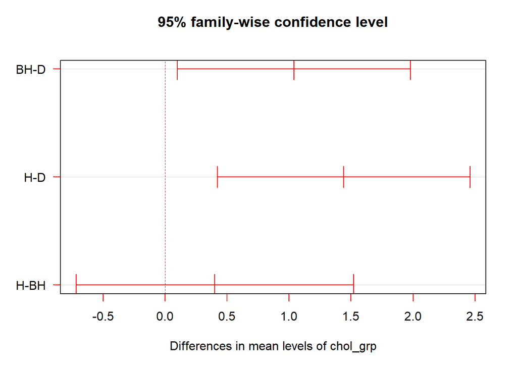

```r
### Visualise

plot(TukeyHSD(obj_aov_chol, conf.level = 0.95),las=1, col = "red")
```

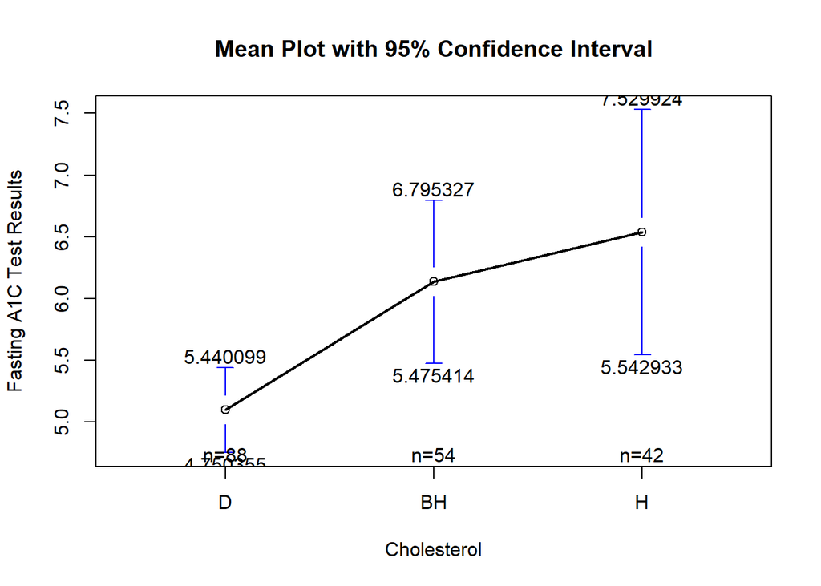

```r
library(gplots)

plotmeans(glyhb~chol_grp, data = diabetes480, ci= TRUE,lwd = 2, main="Mean Plot with 95% Confidence Interval", ylab = "Fasting A1C Test Results", xlab = "Cholesterol")
```

```r
#   Select relevant variables include cholesterol

d480_select <- diabetes480 %>% dplyr::select(age, glyhb, female, chol)

glimpse(d480_select)
```

```
## Observations: 185
## Variables: 4
## $ age    <int> 29, 58, 67, 64, 34, 45, 55, 60, 36, 33, 50, 36, 47, 38,...
## $ glyhb  <dbl> 4.44, 4.64, 4.63, 7.72, 4.81, 4.84, 5.78, 4.77, 4.67, 3...
## $ female <dbl> 1, 1, 0, 0, 0, 0, 1, 1, 0, 1, 1, 0, 0, 1, 1, 1, 0, 0, 0...
## $ chol   <int> 165, 228, 78, 249, 248, 177, 263, 242, 191, 213, 255, 1...
```

```r
#   Compute Correlation matrix

corr_table <- round(cor(d480_select), 3)
corr_table
```

```
##           age  glyhb female  chol
## age     1.000  0.305 -0.072 0.247
## glyhb   0.305  1.000 -0.059 0.312
## female -0.072 -0.059  1.000 0.039
## chol    0.247  0.312  0.039 1.000
```

```r
#   Compute a matrix of correlation p-values

p_mat <- cor_pmat(d480_select)
p_mat
```

```
##                 age        glyhb    female         chol
## age    0.000000e+00 2.351948e-05 0.3270223 6.938993e-04
## glyhb  2.351948e-05 0.000000e+00 0.4280654 1.505587e-05
## female 3.270223e-01 4.280654e-01 0.0000000 6.019597e-01
## chol   6.938993e-04 1.505587e-05 0.6019597 0.000000e+00
```

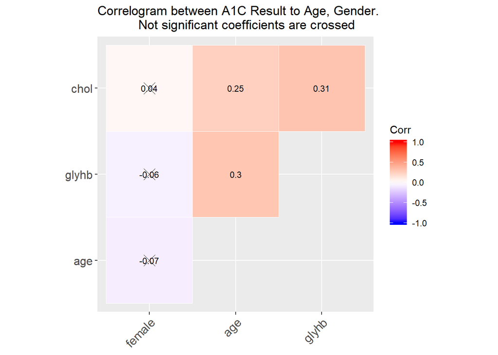

```r
#   Visual the Correlogram barring the no significant coefficient

ggcorrplot(corr_table,
           hc.order = T,
           type = "upper",
           lab = T,
           lab_size = 3,
           method="square",
           colors = c("blue", "white", "red"),
           outline.color = "white",
           p.mat = p_mat,
           title="Correlogram between A1C Result to Age, Gender.
           Not significant coefficients are crossed",
           ggtheme=theme_grey())
```

Visual Analysis:

1. The A1C Mean Result trend positively against the Cholestrol Groups for which the Correlogram indicates a significant positive correlation coefficient of 0.31.
2. From the results, it is observed that there was significant difference for D_BH and H_D pairs. The results indicate that there is a significant risk of getting diabetes once Cholestrol is not maintianed at the desired level.

## Visualize 4: Cholesterol and the interaction with Gender, Frame and Age Group

To answer if High Cholesterols and A1C (glucose level) are correlated positively

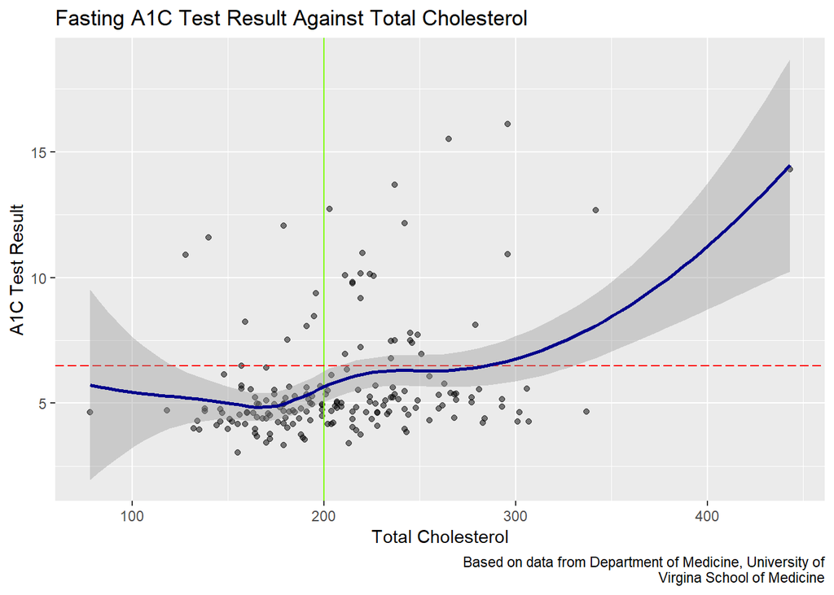

```r
###########################################################################
##    Visualize : A1C Results Against Total Cholesterol (chol) and
##    Cholesterol Group (chol_grp)
#     Both y (glyhb) and x (chol) are continuous / numerical type of data
###########################################################################

diabetes480 %>%
  ggplot(aes(y = glyhb, x = chol), na.rm = TRUE) +
  geom_point(col="black", alpha = 0.5) +
  geom_vline(aes(xintercept=200), col="chartreuse") +
  geom_hline(aes(yintercept=6.5), col="red", linetype="longdash") +
  geom_smooth(color="darkblue", size=1) +
  labs(x = "Total Cholesterol", y = "A1C Test Result",
       caption = "Based on data from Department of Medicine, University of
       Virgina School of Medicine",
       title = "Fasting A1C Test Result Against Total Cholesterol")
```

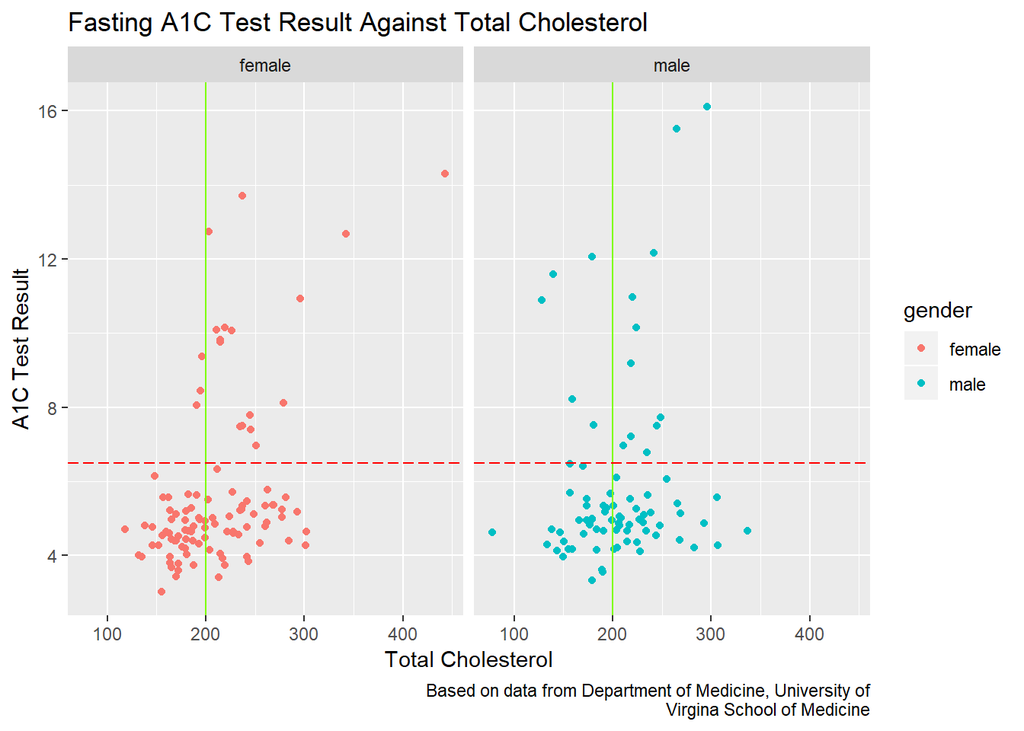

```r
## With Gender included

chol_result <- ggplot(data=diabetes480) +
  geom_point(mapping = aes(x = chol, y = glyhb, col = gender), na.rm = TRUE)+
  geom_vline(xintercept = 200, color = "chartreuse")+
  geom_hline(yintercept = 6.5, color = "red", linetype="longdash")+
  labs(x = "Total Cholesterol", y = "A1C Test Result",
       caption = "Based on data from Department of Medicine, University of
       Virgina School of Medicine",
       title = "Fasting A1C Test Result Against Total Cholesterol")
chol_result + facet_grid(. ~ gender)
```

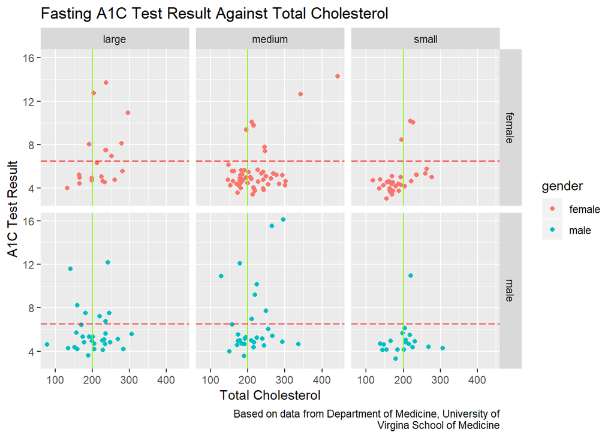

```r
## With Gender and frame included

cholf_result <- ggplot(data=diabetes480) +
  geom_point(mapping = aes(x = chol, y = glyhb, col = gender), na.rm = TRUE)+
  geom_vline(xintercept = 200, color = "chartreuse")+
  geom_hline(yintercept = 6.5, color = "red", linetype="longdash")+
  labs(x = "Total Cholesterol", y = "A1C Test Result",
       caption = "Based on data from Department of Medicine, University of
       Virgina School of Medicine",
       title = "Fasting A1C Test Result Against Total Cholesterol")
cholf_result + facet_grid(gender ~ frame)
```

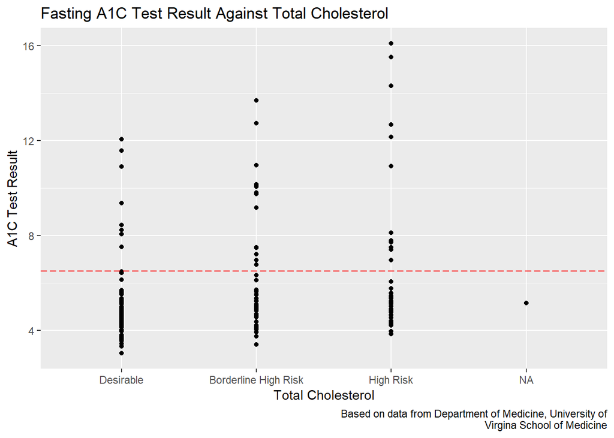

```r
# Reoder chol_grp according to chol

diabetes480$chol_grp <- reorder(diabetes480$chol_grp, diabetes480$chol)

## With chol_grp

ggplot(data=diabetes480) +
  geom_point(mapping = aes(x = chol_grp, y = glyhb), na.rm = TRUE) +
  geom_vline(xintercept = 200, color = "chartreuse") +
  geom_hline(yintercept = 6.5, color = "red", linetype="longdash") +
  labs(x = "Total Cholesterol", y = "A1C Test Result",
       caption = "Based on data from Department of Medicine, University of
       Virgina School of Medicine",
       title = "Fasting A1C Test Result Against Total Cholesterol") +
  scale_x_discrete(labels = c("Desirable","Borderline High Risk",
                              "High Risk"))
```

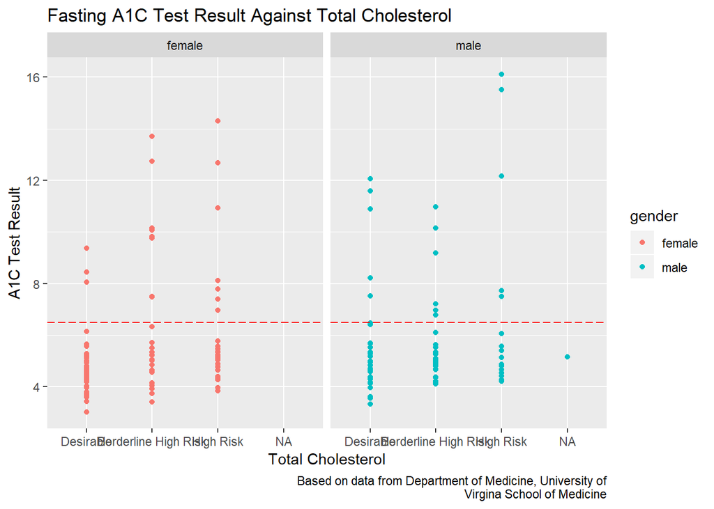

```r
## With chol_grp and gender

cholgrpf_result <- ggplot(data=diabetes480) +
  geom_point(mapping = aes(x = chol_grp, y = glyhb, col = gender)) +
  geom_vline(xintercept = 200, color = "chartreuse") +
  geom_hline(yintercept = 6.5, color = "red", linetype="longdash") +
  labs(x = "Total Cholesterol", y = "A1C Test Result",
       caption = "Based on data from Department of Medicine, University of
       Virgina School of Medicine",
       title = "Fasting A1C Test Result Against Total Cholesterol") +
  scale_x_discrete(labels = c("Desirable","Borderline High Risk",
                              "High Risk"))
cholgrpf_result + facet_grid(. ~ gender)
```

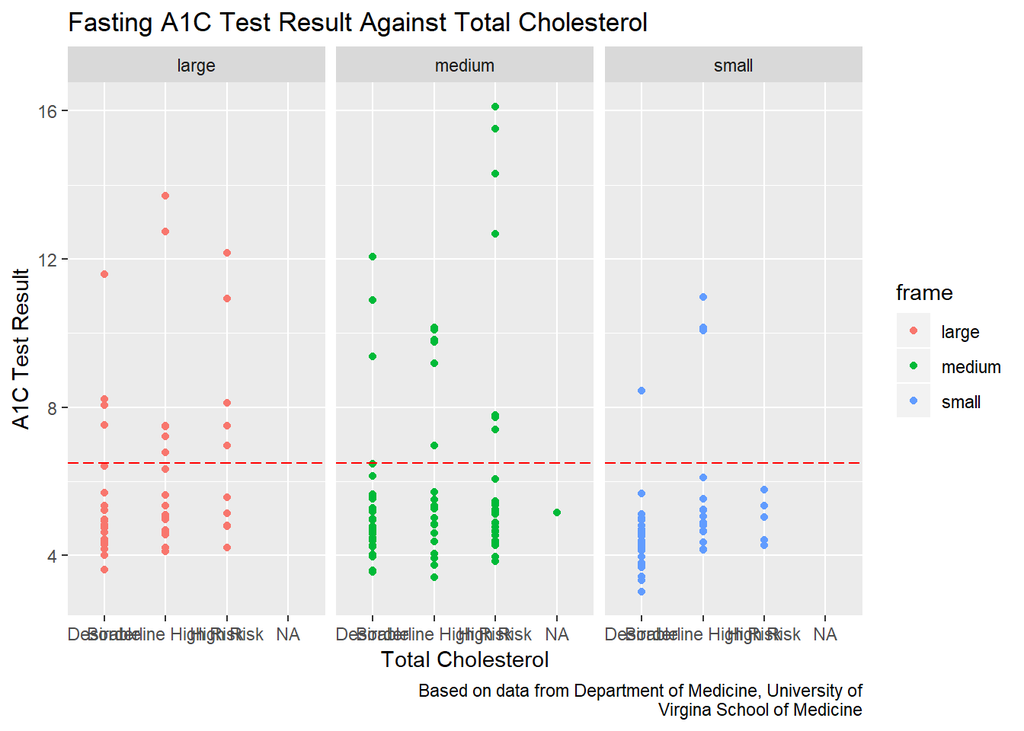

```r
## With chol_grp and frame

cholgrpfr_result <- ggplot(data=diabetes480) +
  geom_point(mapping = aes(x = chol_grp, y = glyhb, col = frame)) +
  geom_vline(xintercept = 200, color = "chartreuse") +
  geom_hline(yintercept = 6.5, color = "red", linetype="longdash") +
  labs(x = "Total Cholesterol", y = "A1C Test Result",
       caption = "Based on data from Department of Medicine, University of
       Virgina School of Medicine",
       title = "Fasting A1C Test Result Against Total Cholesterol") +
  scale_x_discrete(labels = c("Desirable","Borderline High Risk",
                              "High Risk"))
cholgrpfr_result + facet_grid(. ~ frame)
```

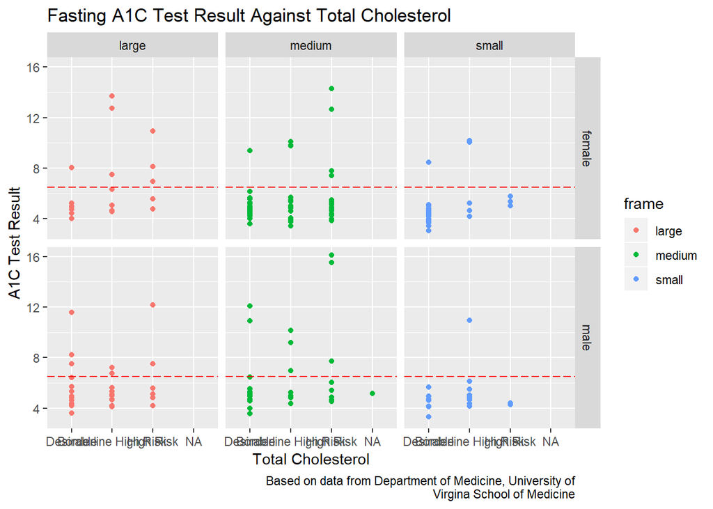

```r
## With chol_grp with gender and frame

cholgrpffr_result <- ggplot(data=diabetes480) +
  geom_point(mapping = aes(x = chol_grp, y = glyhb, col = frame)) +
  geom_vline(xintercept = 200, color = "chartreuse") +
  geom_hline(yintercept = 6.5, color = "red", linetype="longdash") +
  labs(x = "Total Cholesterol", y = "A1C Test Result",
       caption = "Based on data from Department of Medicine, University of
       Virgina School of Medicine",
       title = "Fasting A1C Test Result Against Total Cholesterol") +
  scale_x_discrete(labels = c("Desirable","Borderline High Risk",
                              "High Risk"))
cholgrpffr_result + facet_grid(gender ~ frame)
```

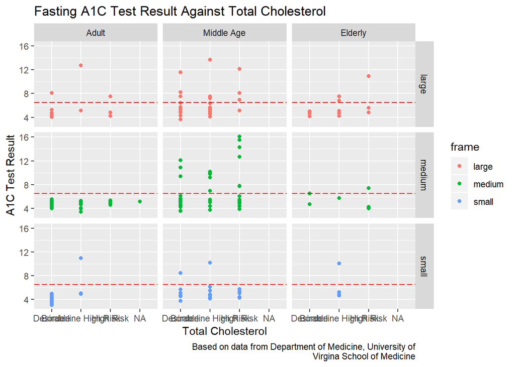

```r
## With chol_grp with age group and frame

diabetes480$age_grp <- reorder(diabetes480$age_grp, diabetes480$age)

cholgrpagefr_result <- ggplot(data=diabetes480) +
  geom_point(mapping = aes(x = chol_grp, y = glyhb, col = frame)) +
  geom_vline(xintercept = 200, color = "chartreuse") +
  geom_hline(yintercept = 6.5, color = "red", linetype="longdash") +
  labs(x = "Total Cholesterol", y = "A1C Test Result",
       caption = "Based on data from Department of Medicine, University of
       Virgina School of Medicine",
       title = "Fasting A1C Test Result Against Total Cholesterol") +
  scale_x_discrete(labels = c("Desirable","Borderline High Risk",
                              "High Risk"))
cholgrpagefr_result + facet_grid(frame ~ age_grp)
```

Visual Analysis:

1. We could not conclude if chol or chol_grp is a better predictor than the other as both gave similiar results without having more insights.
2. Frame could be an interacting factor as it was observed that there was less diabetic risk for small frame observations. In terms of gender, it was observed that females has a higher diabetic risk among those with small frames.
3. Age and Frame: Those in the Middle Age has a higher incidence of diabetic risk across the frames. This could be a strong confounding factor.

## Model 5: To ascertain WHR is a better predictor than BMI

Finally, we want to know whether WHR is a better predictor than BMI since its mean spread for High Risk Group is much higher than those of BMI Groups. Three moderators included are Frame, Gender and Age.

We first define the two competing hypotheses:

1. H0: WHR is a better predictor than BMI
2. HA: WHR is not better predictor than BMI

Next we visualise using the co-relation matrix. After which, we created two models one for BMI and one for WHR and using ANOVA to compare which is a better predictor. Further analysis using standardized regression coefficients.

```r
###########################################################################
##    Modeling : Model and Specify OLS model
##    Question 5 : Investigate if Waist-to-hip ratio (WHR) is a better
##    predictor than BMI on the prevalence of diabetes
###########################################################################

#Set gender: 0 being male; 1 being female

diabetes480_cor <- diabetes480 %>%
  mutate(glyhb_m=rowMeans(diabetes480 %>% dplyr::select(glyhb)),
         bmi_m=rowMeans(diabetes480 %>% dplyr::select(bmi)),
         whr_m=rowMeans(diabetes480 %>% dplyr::select(whr)),
         fem=ifelse(gender == "male",0,1),
         smallf=ifelse(frame == "small",0,1))

## Created and ran a correlational matrix, to see how our variables of interest (within the model) are related.

diabetes480_cor %$%
  cor(tibble(fem, smallf, age, glyhb_m, bmi_m, whr_m)) %>%
  round(.,2)
```

```
##           fem smallf   age glyhb_m bmi_m whr_m
## fem      1.00  -0.05 -0.07   -0.06  0.26 -0.33
## smallf  -0.05   1.00  0.21    0.20  0.40  0.22
## age     -0.07   0.21  1.00    0.31  0.06  0.31
## glyhb_m -0.06   0.20  0.31    1.00  0.13  0.20
## bmi_m    0.26   0.40  0.06    0.13  1.00  0.04
## whr_m   -0.33   0.22  0.31    0.20  0.04  1.00
```

```r
diabetes480_cor %>%
  dplyr::select(fem, smallf, age, glyhb_m, bmi_m, whr_m) %>%
  as.matrix(.) %>%
  Hmisc::rcorr(.) %>%
  tidy(.) %>% as_tibble()
```

```
## # A tibble: 15 x 5
##    column1 column2 estimate     n      p.value
##  * <chr>   <chr>      <dbl> <int>        <dbl>
##  1 fem     smallf   -0.0502   185 0.498
##  2 fem     age      -0.0725   185 0.327
##  3 smallf  age       0.209    185 0.00422
##  4 fem     glyhb_m  -0.0586   185 0.428
##  5 smallf  glyhb_m   0.201    185 0.00615
##  6 age     glyhb_m   0.305    185 0.0000235
##  7 fem     bmi_m     0.263    185 0.000300
##  8 smallf  bmi_m     0.405    185 0.0000000111
##  9 age     bmi_m     0.0638   185 0.388
## 10 glyhb_m bmi_m     0.131    185 0.0747
## 11 fem     whr_m    -0.333    185 0.00000356
## 12 smallf  whr_m     0.218    185 0.00288
## 13 age     whr_m     0.314    185 0.0000130
## 14 glyhb_m whr_m     0.196    185 0.00763
## 15 bmi_m   whr_m     0.0448   185 0.545
```

```r
# Mean-centering transformation

diabetes480_cor2 <- diabetes480_cor %>%
  dplyr::select(glyhb_m, fem, smallf, age, bmi_m, whr_m) %>%
  mutate_at(vars(age:whr_m),
            funs(. - mean(.,na.rm=T)))

corr_table <- round(cor(diabetes480_cor2), 3)
corr_table
```

```
##         glyhb_m    fem smallf    age bmi_m  whr_m
## glyhb_m   1.000 -0.059  0.201  0.305 0.131  0.196
## fem      -0.059  1.000 -0.050 -0.072 0.263 -0.333
## smallf    0.201 -0.050  1.000  0.209 0.405  0.218
## age       0.305 -0.072  0.209  1.000 0.064  0.314
## bmi_m     0.131  0.263  0.405  0.064 1.000  0.045
## whr_m     0.196 -0.333  0.218  0.314 0.045  1.000
```

```r
#   Compute a matrix of correlation p-values

p_mat <- cor_pmat(diabetes480_cor2)
p_mat
```

```
##              glyhb_m          fem       smallf          age        bmi_m
## glyhb_m 0.000000e+00 4.280654e-01 6.151734e-03 2.351948e-05 7.468144e-02
## fem     4.280654e-01 0.000000e+00 4.977890e-01 3.270223e-01 3.001335e-04
## smallf  6.151734e-03 4.977890e-01 0.000000e+00 4.218198e-03 1.109572e-08
## age     2.351948e-05 3.270223e-01 4.218198e-03 0.000000e+00 3.881977e-01
## bmi_m   7.468144e-02 3.001335e-04 1.109572e-08 3.881977e-01 0.000000e+00
## whr_m   7.629874e-03 3.555523e-06 2.877678e-03 1.303483e-05 5.445903e-01
##                whr_m
## glyhb_m 7.629874e-03
## fem     3.555523e-06
## smallf  2.877678e-03
## age     1.303483e-05
## bmi_m   5.445903e-01
## whr_m   0.000000e+00
```

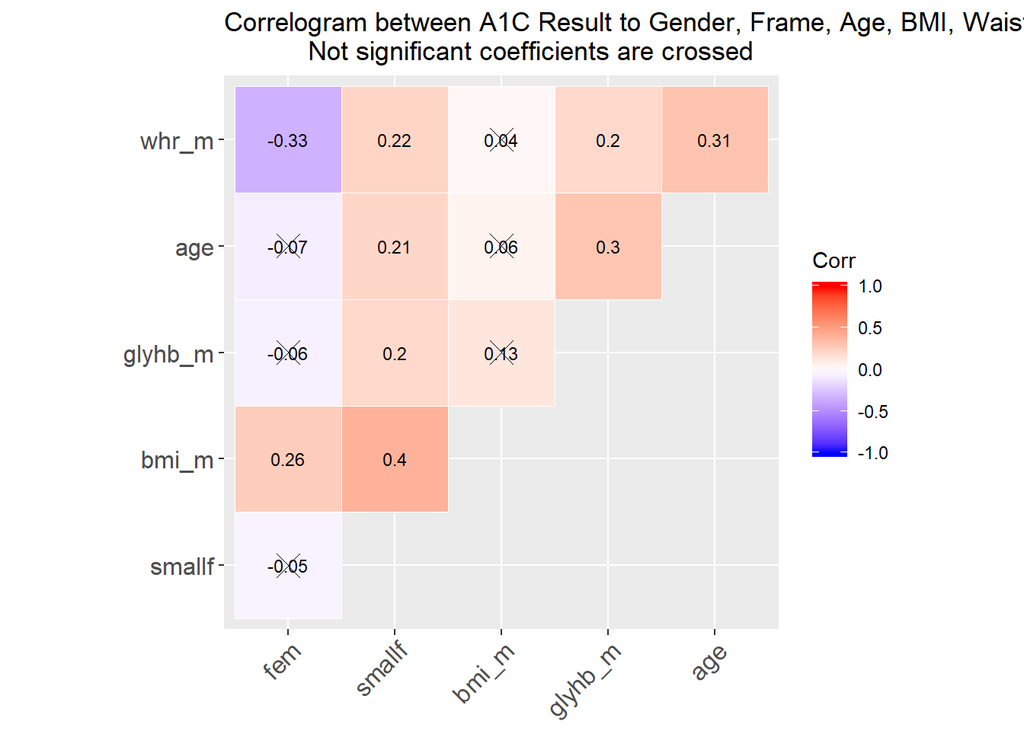

```r
#   Visual the Correlogram barring the no significant coefficient

ggcorrplot(corr_table,
           hc.order = T,
           type = "upper",
           lab = T,
           lab_size = 3,
           method="square",
           colors = c("blue", "white", "red"),
           outline.color = "white",
           p.mat = p_mat,
           title="Correlogram between A1C Result to Gender, Frame, Age, BMI, Waist-Hip Ratio.
           Not significant coefficients are crossed",
           ggtheme=theme_grey())
```

```r
## Result: whr_m has a higher number (0.2) than bmi_m (0.13)

## Specify OLS model
## Model using BMI

model1 = lm(glyhb ~ bmi + gender + age,
             diabetes480)
summary(model1)
```

```
##
## Call:
## lm(formula = glyhb ~ bmi + gender + age, data = diabetes480)
##
## Residuals:
##     Min      1Q  Median      3Q     Max
## -3.0068 -1.1587 -0.5524  0.1541 10.0802
##
## Coefficients:
##             Estimate Std. Error t value Pr(>|t|)
## (Intercept)  2.23634    0.91068   2.456   0.0150 *
## bmi          0.04672    0.02587   1.806   0.0726 .
## gendermale   0.34317    0.34736   0.988   0.3245
## age          0.04218    0.01019   4.138 5.37e-05 ***
## ---
## Signif. codes:  0 '***' 0.001 '**' 0.01 '*' 0.05 '.' 0.1 ' ' 1
##
## Residual standard error: 2.249 on 181 degrees of freedom
## Multiple R-squared:  0.1107, Adjusted R-squared:  0.09595
## F-statistic:  7.51 on 3 and 181 DF,  p-value: 9.16e-05
```